# DAB501 Final Project

## Student Information

- Name: Surbhi Patel
- ID: 0794150

## Instructions

Follow the instructions on the handout provided.

## Packages and Data

```r
library(tidyverse)
library(here)
```

```r
# Replace the _____ with the correct file name
df <- read_csv(here('starbucks.csv'))
```

## MODELING: First pair of variables

### Question 1

Fat is the explanatory variable and it is on the x-axis.

### Question 2

Calories is the response variable and it is on the y-axis.

### Question 3

```r
m1 <- lm(calories~fat,data=df)
summary(m1)
```

```
Call:
lm(formula = calories ~ fat, data = df)

Residuals:
     Min       1Q   Median       3Q      Max
-132.599  -44.130    3.469   54.868  126.134

Coefficients:
            Estimate Std. Error t value Pr(>|t|)
(Intercept)  183.734     17.277   10.63  < 2e-16 ***
fat           11.267      1.117   10.09 1.32e-15 ***
---
Signif. codes:  0 ‘***’ 0.001 ‘**’ 0.01 ‘*’ 0.05 ‘.’ 0.1 ‘ ’ 1

Residual standard error: 69.1 on 75 degrees of freedom
Multiple R-squared:  0.5756,    Adjusted R-squared:  0.5699
F-statistic: 101.7 on 1 and 75 DF,  p-value: 1.32e-15
```

### Question 4

The equation is calories^ = (Y-intercept) + (Slope)*fat

Here Y-intercept = (183.734) and Slope = 11.267.

Equation: $\hat{\rm calories} = 183.734 + 11.267*{\rm fat}$

### Question 5

The intercept shows the value of the calories in the food items when values of fat in food item is equal to zero.

### Question 6

There is a meaning to the intercept because in this model, regression line is cross to the y-axis and it also equal to zero.

## MODELING: Second pair of variables

### Question 1

Carb is the explanatory variable and it is on the x-axis.

### Question 2

Calories is the response variable and it is on the y-axis.

### Question 3

```r
m2 <- lm(calories~carb,data=df)
summary(m2)
```

```
Call:
lm(formula = calories ~ carb, data = df)

Residuals:
     Min       1Q   Median       3Q      Max
-151.962  -70.556   -0.636   54.908  179.444

Coefficients:
            Estimate Std. Error t value Pr(>|t|)
(Intercept) 146.0204    25.9186   5.634 2.93e-07 ***
carb          4.2971     0.5424   7.923 1.67e-11 ***
---
Signif. codes:  0 ‘***’ 0.001 ‘**’ 0.01 ‘*’ 0.05 ‘.’ 0.1 ‘ ’ 1

Residual standard error: 78.26 on 75 degrees of freedom
Multiple R-squared:  0.4556,    Adjusted R-squared:  0.4484
F-statistic: 62.77 on 1 and 75 DF,  p-value: 1.673e-11
```

### Question 4

The equation is calories^ = (Y-intercept) + (Slope)*carb

Here Y-intercept = (146.0204) and Slope = 4.2971.

Equation: $\hat{\rm calories} = 146.0204 + 4.2971*{\rm carb}$

### Question 5

The intercept shows the value of the calories in the food items when the values of carb in the food items is equal to zero.

### Question 6

There is no meaning to the intercept because in this model, regression line is only equal to zero.

## MODEL ASSESSMENT

### Question 1

Multiple R-squared metric is used to choose between the two models created.

### Question 2

R-squared is a statistical measure in a regression model and the values of R-squared indicates accuracy of the data matches to the regression model. The values of R-squared is in between 0 and 1. If R-squared value is higher, our model is best fit in the observation.

R-squared metric is good for comparing models because it gives proper accuracy to the model.

### Question 3

According to this metric, model-1(calories~fat) is the best as compared to model-2(calories~card) because in model 1, a value of multiple R-squared is higher than model 2.

## MODEL DIAGNOSTICS

### Question 1

```r
df_mod<-df %>% mutate(pred_calories = 183.734 + 11.267*fat, residuals = calories-pred_calories)

df_mod
```

| calories | fat | carb | pred_calories | residuals |
| --- | --- | --- | --- | --- |
| 350 | 8.0 | 67 | 273.8700 | 76.1300 |
| 350 | 9.0 | 64 | 285.1370 | 64.8630 |
| 420 | 20.0 | 59 | 409.0740 | 10.9260 |
| 490 | 19.0 | 75 | 397.8070 | 92.1930 |
| 130 | 6.0 | 17 | 251.3360 | -121.3360 |
| 370 | 14.0 | 47 | 341.4720 | 28.5280 |
| 460 | 22.0 | 61 | 431.6080 | 28.3920 |
| 370 | 14.0 | 55 | 341.4720 | 28.5280 |
| 310 | 18.0 | 32 | 386.5400 | -76.5400 |
| 420 | 25.0 | 39 | 465.4090 | -45.4090 |

[output cut: 67 more lines]

### Question 2

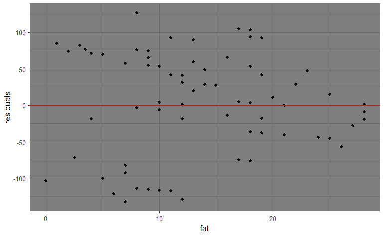

```r
ggplot(df_mod,aes(x=fat,y=residuals))+
geom_point()+
  geom_hline(yintercept = 0, colour='red')+theme_dark()
```

- If there is pattern in residual plot, linearity condition is not met.
- If there is no apparent patter, linearity is met

There is no apparent pattern in the residuals plot so this condition met. This indicates linearity of the relationship between fat and calories.

### Question 3

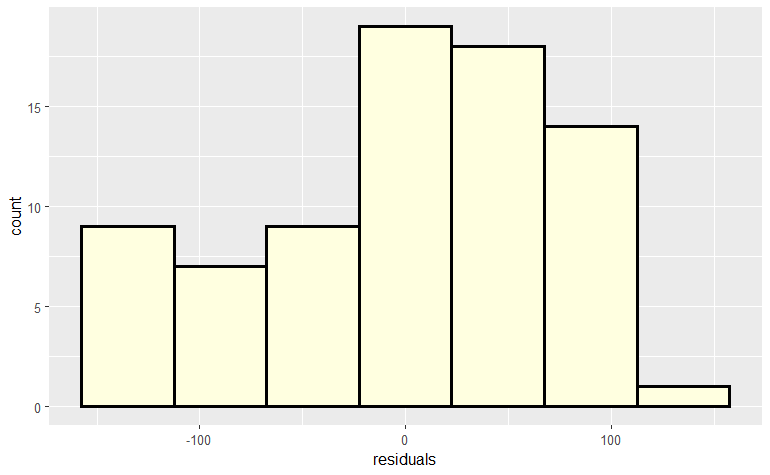

```r
ggplot(df_mod, aes(x=residuals))+

 geom_histogram(fill='lightyellow',color='black',binwidth=45,alpha=5,size=1.070)
```

### Question 4

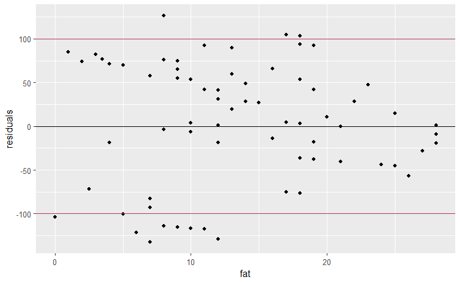

```r
ggplot(df_mod, aes(x=fat, y=residuals))+

 geom_point()+

 geom_hline(yintercept=0)+

 geom_hline(yintercept=100, colour='maroon')+

 geom_hline(yintercept=-100, colour='maroon')
```